# Risk Factor Analysis

## Outcome Variable

**Outcome Variable:** y_rate_haz

## Predictor Variables

**Intervention Variable:** parity

**Adjustment Set:**

- arm
- W_mage
- meducyrs
- feducyrs
- W_mhtcm
- W_mwtkg
- W_mbmi
- vagbrth
- single
- delta_W_mage
- delta_meducyrs
- delta_feducyrs
- delta_W_mhtcm
- delta_W_mwtkg
- delta_W_mbmi
- delta_vagbrth
- delta_single

## Stratifying Variables

The analysis was stratified on these variable(s):

- agecat
- studyid
- country

## Data Summary

| agecat | studyid | country | parity | n_cell | n | outcome_variable |
| --- | --- | --- | --- | --- | --- | --- |
| 0-3 months | ki1000304b-SAS-CompFeed | INDIA | 1 | 344 | 1261 | y_rate_haz |
| 0-3 months | ki1000304b-SAS-CompFeed | INDIA | 2 | 298 | 1261 | y_rate_haz |
| 0-3 months | ki1000304b-SAS-CompFeed | INDIA | 3+ | 619 | 1261 | y_rate_haz |
| 0-3 months | ki1017093b-PROVIDE | BANGLADESH | 1 | 242 | 640 | y_rate_haz |
| 0-3 months | ki1017093b-PROVIDE | BANGLADESH | 2 | 226 | 640 | y_rate_haz |
| 0-3 months | ki1017093b-PROVIDE | BANGLADESH | 3+ | 172 | 640 | y_rate_haz |
| 0-3 months | ki1101329-Keneba | GAMBIA | 1 | 130 | 1145 | y_rate_haz |
| 0-3 months | ki1101329-Keneba | GAMBIA | 2 | 113 | 1145 | y_rate_haz |
| 0-3 months | ki1101329-Keneba | GAMBIA | 3+ | 902 | 1145 | y_rate_haz |
| 0-3 months | ki1113344-GMS-Nepal | NEPAL | 1 | 137 | 509 | y_rate_haz |
| 0-3 months | ki1113344-GMS-Nepal | NEPAL | 2 | 129 | 509 | y_rate_haz |
| 0-3 months | ki1113344-GMS-Nepal | NEPAL | 3+ | 243 | 509 | y_rate_haz |
| 0-3 months | ki1126311-ZVITAMBO | ZIMBABWE | 1 | 3100 | 7981 | y_rate_haz |
| 0-3 months | ki1126311-ZVITAMBO | ZIMBABWE | 2 | 2478 | 7981 | y_rate_haz |
| 0-3 months | ki1126311-ZVITAMBO | ZIMBABWE | 3+ | 2403 | 7981 | y_rate_haz |
| 0-3 months | ki1135781-COHORTS | GUATEMALA | 1 | 93 | 728 | y_rate_haz |
| 0-3 months | ki1135781-COHORTS | GUATEMALA | 2 | 111 | 728 | y_rate_haz |
| 0-3 months | ki1135781-COHORTS | GUATEMALA | 3+ | 524 | 728 | y_rate_haz |
| 0-3 months | ki1135781-COHORTS | INDIA | 1 | 671 | 4021 | y_rate_haz |
| 0-3 months | ki1135781-COHORTS | INDIA | 2 | 1015 | 4021 | y_rate_haz |
| 0-3 months | ki1135781-COHORTS | INDIA | 3+ | 2335 | 4021 | y_rate_haz |
| 0-3 months | kiGH5241-JiVitA-3 | BANGLADESH | 1 | 6339 | 19879 | y_rate_haz |
| 0-3 months | kiGH5241-JiVitA-3 | BANGLADESH | 2 | 6881 | 19879 | y_rate_haz |
| 0-3 months | kiGH5241-JiVitA-3 | BANGLADESH | 3+ | 6659 | 19879 | y_rate_haz |
| 3-6 months | ki1000304b-SAS-CompFeed | INDIA | 1 | 299 | 1124 | y_rate_haz |
| 3-6 months | ki1000304b-SAS-CompFeed | INDIA | 2 | 261 | 1124 | y_rate_haz |
| 3-6 months | ki1000304b-SAS-CompFeed | INDIA | 3+ | 564 | 1124 | y_rate_haz |
| 3-6 months | ki1017093b-PROVIDE | BANGLADESH | 1 | 214 | 598 | y_rate_haz |
| 3-6 months | ki1017093b-PROVIDE | BANGLADESH | 2 | 221 | 598 | y_rate_haz |
| 3-6 months | ki1017093b-PROVIDE | BANGLADESH | 3+ | 163 | 598 | y_rate_haz |

[output cut: 156 more lines]

The following strata were considered:

- agecat: 0-3 months, studyid: ki1000304b-SAS-CompFeed, country: INDIA
- agecat: 0-3 months, studyid: ki1017093b-PROVIDE, country: BANGLADESH
- agecat: 0-3 months, studyid: ki1101329-Keneba, country: GAMBIA
- agecat: 0-3 months, studyid: ki1113344-GMS-Nepal, country: NEPAL
- agecat: 0-3 months, studyid: ki1126311-ZVITAMBO, country: ZIMBABWE
- agecat: 0-3 months, studyid: ki1135781-COHORTS, country: GUATEMALA
- agecat: 0-3 months, studyid: ki1135781-COHORTS, country: INDIA
- agecat: 0-3 months, studyid: kiGH5241-JiVitA-3, country: BANGLADESH
- agecat: 12-15 months, studyid: ki1000304b-SAS-CompFeed, country: INDIA
- agecat: 12-15 months, studyid: ki1000304b-SAS-FoodSuppl, country: INDIA
- agecat: 12-15 months, studyid: ki1017093b-PROVIDE, country: BANGLADESH
- agecat: 12-15 months, studyid: ki1066203-TanzaniaChild2, country: TANZANIA, UNITED REPUBLIC OF
- agecat: 12-15 months, studyid: ki1101329-Keneba, country: GAMBIA
- agecat: 12-15 months, studyid: ki1113344-GMS-Nepal, country: NEPAL
- agecat: 12-15 months, studyid: ki1126311-ZVITAMBO, country: ZIMBABWE
- agecat: 12-15 months, studyid: ki1135781-COHORTS, country: GUATEMALA
- agecat: 15-18 months, studyid: ki1000304b-SAS-CompFeed, country: INDIA
- agecat: 15-18 months, studyid: ki1000304b-SAS-FoodSuppl, country: INDIA
- agecat: 15-18 months, studyid: ki1017093b-PROVIDE, country: BANGLADESH
- agecat: 15-18 months, studyid: ki1066203-TanzaniaChild2, country: TANZANIA, UNITED REPUBLIC OF
- agecat: 15-18 months, studyid: ki1101329-Keneba, country: GAMBIA
- agecat: 15-18 months, studyid: ki1113344-GMS-Nepal, country: NEPAL
- agecat: 15-18 months, studyid: ki1126311-ZVITAMBO, country: ZIMBABWE
- agecat: 15-18 months, studyid: ki1135781-COHORTS, country: GUATEMALA
- agecat: 18-21 months, studyid: ki1017093b-PROVIDE, country: BANGLADESH
- agecat: 18-21 months, studyid: ki1066203-TanzaniaChild2, country: TANZANIA, UNITED REPUBLIC OF
- agecat: 18-21 months, studyid: ki1101329-Keneba, country: GAMBIA
- agecat: 18-21 months, studyid: ki1113344-GMS-Nepal, country: NEPAL
- agecat: 18-21 months, studyid: ki1126311-ZVITAMBO, country: ZIMBABWE
- agecat: 18-21 months, studyid: ki1135781-COHORTS, country: GUATEMALA
- agecat: 21-24 months, studyid: ki1017093b-PROVIDE, country: BANGLADESH
- agecat: 21-24 months, studyid: ki1101329-Keneba, country: GAMBIA
- agecat: 21-24 months, studyid: ki1113344-GMS-Nepal, country: NEPAL
- agecat: 21-24 months, studyid: ki1126311-ZVITAMBO, country: ZIMBABWE
- agecat: 21-24 months, studyid: ki1135781-COHORTS, country: GUATEMALA
- agecat: 3-6 months, studyid: ki1000304b-SAS-CompFeed, country: INDIA
- agecat: 3-6 months, studyid: ki1017093b-PROVIDE, country: BANGLADESH
- agecat: 3-6 months, studyid: ki1066203-TanzaniaChild2, country: TANZANIA, UNITED REPUBLIC OF
- agecat: 3-6 months, studyid: ki1101329-Keneba, country: GAMBIA
- agecat: 3-6 months, studyid: ki1113344-GMS-Nepal, country: NEPAL
- agecat: 3-6 months, studyid: ki1126311-ZVITAMBO, country: ZIMBABWE
- agecat: 3-6 months, studyid: ki1135781-COHORTS, country: GUATEMALA
- agecat: 3-6 months, studyid: ki1135781-COHORTS, country: INDIA
- agecat: 3-6 months, studyid: kiGH5241-JiVitA-3, country: BANGLADESH
- agecat: 6-9 months, studyid: ki1000304b-SAS-CompFeed, country: INDIA
- agecat: 6-9 months, studyid: ki1000304b-SAS-FoodSuppl, country: INDIA
- agecat: 6-9 months, studyid: ki1017093b-PROVIDE, country: BANGLADESH
- agecat: 6-9 months, studyid: ki1066203-TanzaniaChild2, country: TANZANIA, UNITED REPUBLIC OF
- agecat: 6-9 months, studyid: ki1101329-Keneba, country: GAMBIA
- agecat: 6-9 months, studyid: ki1113344-GMS-Nepal, country: NEPAL
- agecat: 6-9 months, studyid: ki1126311-ZVITAMBO, country: ZIMBABWE
- agecat: 6-9 months, studyid: ki1135781-COHORTS, country: GUATEMALA
- agecat: 6-9 months, studyid: ki1135781-COHORTS, country: INDIA
- agecat: 9-12 months, studyid: ki1000304b-SAS-CompFeed, country: INDIA
- agecat: 9-12 months, studyid: ki1000304b-SAS-FoodSuppl, country: INDIA
- agecat: 9-12 months, studyid: ki1017093b-PROVIDE, country: BANGLADESH
- agecat: 9-12 months, studyid: ki1066203-TanzaniaChild2, country: TANZANIA, UNITED REPUBLIC OF
- agecat: 9-12 months, studyid: ki1101329-Keneba, country: GAMBIA
- agecat: 9-12 months, studyid: ki1113344-GMS-Nepal, country: NEPAL
- agecat: 9-12 months, studyid: ki1126311-ZVITAMBO, country: ZIMBABWE
- agecat: 9-12 months, studyid: ki1135781-COHORTS, country: GUATEMALA
- agecat: 9-12 months, studyid: ki1135781-COHORTS, country: INDIA

### Dropped Strata

Some strata were dropped due to rare outcomes:

- agecat: 6-9 months, studyid: ki1000304b-SAS-FoodSuppl, country: INDIA
- agecat: 9-12 months, studyid: ki1000304b-SAS-FoodSuppl, country: INDIA
- agecat: 12-15 months, studyid: ki1000304b-SAS-FoodSuppl, country: INDIA
- agecat: 15-18 months, studyid: ki1000304b-SAS-FoodSuppl, country: INDIA
- agecat: 18-21 months, studyid: ki1066203-TanzaniaChild2, country: TANZANIA, UNITED REPUBLIC OF

## Methods Detail

We’re interested in the causal parameters $E[Y_a]$ for all values of $a \in \mathcal{A}$. These parameters represent the mean outcome if, possibly contrary to fact, we intervened to set all units to have $A=a$. Under the randomization and positivity assumptions, these are identified by the statistical parameters $\psi_a=E_W[E_{Y|A,W}(Y|A=a,W)]$. In addition, we’re interested in the mean of $Y$, $E[Y]$ under no intervention (the observed mean). We will estimate these parameters by using SuperLearner to fit the relevant likelihood factors – $E_{Y|A,W}(Y|A=a,W)$ and $p(A=a|W)$, and then updating our likelihood fit using a joint TMLE.

For unadjusted analyses ($W=\{\}$), initial likelihoods were estimated using Lrnr_glm to estimate the simple $E(Y|A)$ and Lrnr_mean to estimate $p(A)$. For adjusted analyses, a small library containing Lrnr_glmnet, Lrnr_xgboost, and Lrnr_mean was used.

Having estimated these parameters, we will then use the delta method to estimate relative risks and attributable risks relative to a prespecified baseline level of $A$.

# Results Detail

## Results Plots

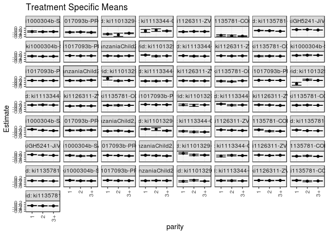

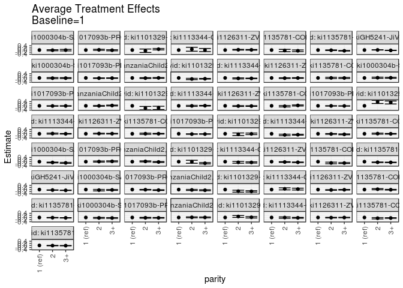

[figure not shown]

## Results Table

### Parameter: TSM

| agecat | studyid | country | intervention_level | baseline_level | estimate | ci_lower | ci_upper |
| --- | --- | --- | --- | --- | --- | --- | --- |
| 0-3 months | ki1000304b-SAS-CompFeed | INDIA | 1 | NA | -0.1177588 | -0.1808184 | -0.0546993 |
| 0-3 months | ki1000304b-SAS-CompFeed | INDIA | 2 | NA | -0.1343687 | -0.1661231 | -0.1026143 |
| 0-3 months | ki1000304b-SAS-CompFeed | INDIA | 3+ | NA | -0.1259672 | -0.1550351 | -0.0968993 |
| 0-3 months | ki1017093b-PROVIDE | BANGLADESH | 1 | NA | -0.1802435 | -0.2199325 | -0.1405546 |
| 0-3 months | ki1017093b-PROVIDE | BANGLADESH | 2 | NA | -0.1609110 | -0.1974202 | -0.1244017 |
| 0-3 months | ki1017093b-PROVIDE | BANGLADESH | 3+ | NA | -0.1980596 | -0.2389838 | -0.1571354 |
| 0-3 months | ki1101329-Keneba | GAMBIA | 1 | NA | -0.3550246 | -0.4115142 | -0.2985351 |
| 0-3 months | ki1101329-Keneba | GAMBIA | 2 | NA | -0.4236092 | -0.5775387 | -0.2696797 |
| 0-3 months | ki1101329-Keneba | GAMBIA | 3+ | NA | -0.2780550 | -0.3147656 | -0.2413445 |
| 0-3 months | ki1113344-GMS-Nepal | NEPAL | 1 | NA | -0.0588334 | -0.1998029 | 0.0821361 |
| 0-3 months | ki1113344-GMS-Nepal | NEPAL | 2 | NA | 0.0168624 | -0.1066511 | 0.1403759 |
| 0-3 months | ki1113344-GMS-Nepal | NEPAL | 3+ | NA | -0.0584931 | -0.1008991 | -0.0160872 |
| 0-3 months | ki1126311-ZVITAMBO | ZIMBABWE | 1 | NA | -0.1327937 | -0.1601539 | -0.1054335 |
| 0-3 months | ki1126311-ZVITAMBO | ZIMBABWE | 2 | NA | -0.1060841 | -0.1320020 | -0.0801662 |
| 0-3 months | ki1126311-ZVITAMBO | ZIMBABWE | 3+ | NA | -0.1150578 | -0.1388481 | -0.0912675 |
| 0-3 months | ki1135781-COHORTS | GUATEMALA | 1 | NA | -0.4823087 | -0.5541899 | -0.4104276 |
| 0-3 months | ki1135781-COHORTS | GUATEMALA | 2 | NA | -0.5291281 | -0.6127504 | -0.4455058 |
| 0-3 months | ki1135781-COHORTS | GUATEMALA | 3+ | NA | -0.5525813 | -0.5815282 | -0.5236344 |
| 0-3 months | ki1135781-COHORTS | INDIA | 1 | NA | -0.0186824 | -0.0422463 | 0.0048816 |
| 0-3 months | ki1135781-COHORTS | INDIA | 2 | NA | -0.0375062 | -0.0610446 | -0.0139678 |
| 0-3 months | ki1135781-COHORTS | INDIA | 3+ | NA | -0.0879700 | -0.1005699 | -0.0753701 |
| 0-3 months | kiGH5241-JiVitA-3 | BANGLADESH | 1 | NA | 0.0629975 | 0.0502085 | 0.0757865 |
| 0-3 months | kiGH5241-JiVitA-3 | BANGLADESH | 2 | NA | 0.0732088 | 0.0620066 | 0.0844110 |
| 0-3 months | kiGH5241-JiVitA-3 | BANGLADESH | 3+ | NA | 0.0302628 | 0.0195705 | 0.0409551 |
| 3-6 months | ki1000304b-SAS-CompFeed | INDIA | 1 | NA | 0.0577397 | 0.0237878 | 0.0916916 |
| 3-6 months | ki1000304b-SAS-CompFeed | INDIA | 2 | NA | -0.0197798 | -0.0379294 | -0.0016302 |
| 3-6 months | ki1000304b-SAS-CompFeed | INDIA | 3+ | NA | -0.0579872 | -0.0820840 | -0.0338903 |
| 3-6 months | ki1017093b-PROVIDE | BANGLADESH | 1 | NA | -0.0295546 | -0.0677989 | 0.0086897 |
| 3-6 months | ki1017093b-PROVIDE | BANGLADESH | 2 | NA | -0.0218849 | -0.0587050 | 0.0149352 |
| 3-6 months | ki1017093b-PROVIDE | BANGLADESH | 3+ | NA | 0.0011595 | -0.0358946 | 0.0382135 |

[output cut: 141 more lines]

### Parameter: E(Y)

| agecat | studyid | country | intervention_level | baseline_level | estimate | ci_lower | ci_upper |
| --- | --- | --- | --- | --- | --- | --- | --- |
| 0-3 months | ki1000304b-SAS-CompFeed | INDIA | NA | NA | -0.1273566 | -0.1543372 | -0.1003761 |
| 0-3 months | ki1017093b-PROVIDE | BANGLADESH | NA | NA | -0.1880402 | -0.2054115 | -0.1706689 |
| 0-3 months | ki1101329-Keneba | GAMBIA | NA | NA | -0.2821028 | -0.3073160 | -0.2568895 |
| 0-3 months | ki1113344-GMS-Nepal | NEPAL | NA | NA | -0.0317680 | -0.0569509 | -0.0065852 |
| 0-3 months | ki1126311-ZVITAMBO | ZIMBABWE | NA | NA | -0.1402688 | -0.1504985 | -0.1300391 |
| 0-3 months | ki1135781-COHORTS | GUATEMALA | NA | NA | -0.5371921 | -0.5589495 | -0.5154346 |
| 0-3 months | ki1135781-COHORTS | INDIA | NA | NA | -0.0677269 | -0.0765502 | -0.0589035 |
| 0-3 months | kiGH5241-JiVitA-3 | BANGLADESH | NA | NA | 0.0588418 | 0.0539208 | 0.0637627 |
| 3-6 months | ki1000304b-SAS-CompFeed | INDIA | NA | NA | -0.0166348 | -0.0360336 | 0.0027639 |
| 3-6 months | ki1017093b-PROVIDE | BANGLADESH | NA | NA | -0.0269625 | -0.0428628 | -0.0110622 |
| 3-6 months | ki1066203-TanzaniaChild2 | TANZANIA, UNITED REPUBLIC OF | NA | NA | -0.0841486 | -0.1008599 | -0.0674373 |
| 3-6 months | ki1101329-Keneba | GAMBIA | NA | NA | -0.0278645 | -0.0482582 | -0.0074707 |
| 3-6 months | ki1113344-GMS-Nepal | NEPAL | NA | NA | -0.1613977 | -0.1800128 | -0.1427826 |
| 3-6 months | ki1126311-ZVITAMBO | ZIMBABWE | NA | NA | -0.0012924 | -0.0104920 | 0.0079073 |
| 3-6 months | ki1135781-COHORTS | GUATEMALA | NA | NA | -0.0963382 | -0.1109683 | -0.0817082 |
| 3-6 months | ki1135781-COHORTS | INDIA | NA | NA | -0.0633737 | -0.0703095 | -0.0564379 |
| 3-6 months | kiGH5241-JiVitA-3 | BANGLADESH | NA | NA | -0.0034426 | -0.0083086 | 0.0014234 |
| 6-9 months | ki1000304b-SAS-CompFeed | INDIA | NA | NA | -0.0823482 | -0.0898643 | -0.0748321 |
| 6-9 months | ki1017093b-PROVIDE | BANGLADESH | NA | NA | -0.0614264 | -0.0722690 | -0.0505838 |
| 6-9 months | ki1066203-TanzaniaChild2 | TANZANIA, UNITED REPUBLIC OF | NA | NA | -0.0525285 | -0.0687206 | -0.0363364 |
| 6-9 months | ki1101329-Keneba | GAMBIA | NA | NA | -0.0045762 | -0.0287122 | 0.0195598 |
| 6-9 months | ki1113344-GMS-Nepal | NEPAL | NA | NA | -0.0438931 | -0.0614010 | -0.0263853 |
| 6-9 months | ki1126311-ZVITAMBO | ZIMBABWE | NA | NA | -0.0315646 | -0.0399465 | -0.0231828 |
| 6-9 months | ki1135781-COHORTS | GUATEMALA | NA | NA | -0.1207546 | -0.1326448 | -0.1088643 |
| 6-9 months | ki1135781-COHORTS | INDIA | NA | NA | -0.0985796 | -0.1048064 | -0.0923527 |
| 9-12 months | ki1000304b-SAS-CompFeed | INDIA | NA | NA | -0.0811963 | -0.0946758 | -0.0677169 |
| 9-12 months | ki1017093b-PROVIDE | BANGLADESH | NA | NA | -0.0630470 | -0.0740183 | -0.0520757 |
| 9-12 months | ki1066203-TanzaniaChild2 | TANZANIA, UNITED REPUBLIC OF | NA | NA | -0.0652640 | -0.0796167 | -0.0509113 |
| 9-12 months | ki1101329-Keneba | GAMBIA | NA | NA | -0.1061496 | -0.1248815 | -0.0874176 |
| 9-12 months | ki1113344-GMS-Nepal | NEPAL | NA | NA | -0.0798239 | -0.0934194 | -0.0662284 |
| 9-12 months | ki1126311-ZVITAMBO | ZIMBABWE | NA | NA | -0.0590759 | -0.0665312 | -0.0516205 |
| 9-12 months | ki1135781-COHORTS | GUATEMALA | NA | NA | -0.0887143 | -0.0986894 | -0.0787393 |
| 9-12 months | ki1135781-COHORTS | INDIA | NA | NA | -0.0933036 | -0.0995020 | -0.0871051 |
| 12-15 months | ki1000304b-SAS-CompFeed | INDIA | NA | NA | -0.0847390 | -0.0988912 | -0.0705868 |
| 12-15 months | ki1017093b-PROVIDE | BANGLADESH | NA | NA | -0.0409107 | -0.0510053 | -0.0308161 |
| 12-15 months | ki1066203-TanzaniaChild2 | TANZANIA, UNITED REPUBLIC OF | NA | NA | -0.0649105 | -0.0794330 | -0.0503881 |
| 12-15 months | ki1101329-Keneba | GAMBIA | NA | NA | -0.0554331 | -0.0683830 | -0.0424832 |
| 12-15 months | ki1113344-GMS-Nepal | NEPAL | NA | NA | -0.0667249 | -0.0775841 | -0.0558657 |
| 12-15 months | ki1126311-ZVITAMBO | ZIMBABWE | NA | NA | -0.0622748 | -0.0728257 | -0.0517239 |
| 12-15 months | ki1135781-COHORTS | GUATEMALA | NA | NA | -0.0875200 | -0.0977014 | -0.0773386 |
| 15-18 months | ki1000304b-SAS-CompFeed | INDIA | NA | NA | -0.0117156 | -0.0214328 | -0.0019983 |
| 15-18 months | ki1017093b-PROVIDE | BANGLADESH | NA | NA | -0.0376437 | -0.0463882 | -0.0288992 |
| 15-18 months | ki1066203-TanzaniaChild2 | TANZANIA, UNITED REPUBLIC OF | NA | NA | -0.0189489 | -0.0345324 | -0.0033654 |
| 15-18 months | ki1101329-Keneba | GAMBIA | NA | NA | -0.0289062 | -0.0415733 | -0.0162391 |
| 15-18 months | ki1113344-GMS-Nepal | NEPAL | NA | NA | -0.0689576 | -0.0815283 | -0.0563869 |
| 15-18 months | ki1126311-ZVITAMBO | ZIMBABWE | NA | NA | -0.0623481 | -0.0733140 | -0.0513822 |
| 15-18 months | ki1135781-COHORTS | GUATEMALA | NA | NA | -0.0545580 | -0.0655035 | -0.0436124 |
| 18-21 months | ki1017093b-PROVIDE | BANGLADESH | NA | NA | -0.0109399 | -0.0190984 | -0.0027814 |
| 18-21 months | ki1101329-Keneba | GAMBIA | NA | NA | -0.0220748 | -0.0349179 | -0.0092317 |
| 18-21 months | ki1113344-GMS-Nepal | NEPAL | NA | NA | 0.0155926 | 0.0038526 | 0.0273327 |
| 18-21 months | ki1126311-ZVITAMBO | ZIMBABWE | NA | NA | -0.0689095 | -0.0806852 | -0.0571338 |
| 18-21 months | ki1135781-COHORTS | GUATEMALA | NA | NA | -0.0194829 | -0.0293542 | -0.0096117 |
| 21-24 months | ki1017093b-PROVIDE | BANGLADESH | NA | NA | 0.0462342 | 0.0375872 | 0.0548812 |
| 21-24 months | ki1101329-Keneba | GAMBIA | NA | NA | 0.0194181 | 0.0072915 | 0.0315446 |
| 21-24 months | ki1113344-GMS-Nepal | NEPAL | NA | NA | 0.0481269 | 0.0325947 | 0.0636591 |
| 21-24 months | ki1126311-ZVITAMBO | ZIMBABWE | NA | NA | 0.0172279 | 0.0047469 | 0.0297089 |
| 21-24 months | ki1135781-COHORTS | GUATEMALA | NA | NA | -0.0058090 | -0.0136683 | 0.0020502 |

### Parameter: ATE

| agecat | studyid | country | intervention_level | baseline_level | estimate | ci_lower | ci_upper |
| --- | --- | --- | --- | --- | --- | --- | --- |
| 0-3 months | ki1000304b-SAS-CompFeed | INDIA | 1 | 1 | 0.0000000 | 0.0000000 | 0.0000000 |
| 0-3 months | ki1000304b-SAS-CompFeed | INDIA | 2 | 1 | -0.0166099 | -0.0706861 | 0.0374664 |
| 0-3 months | ki1000304b-SAS-CompFeed | INDIA | 3+ | 1 | -0.0082084 | -0.0787197 | 0.0623028 |
| 0-3 months | ki1017093b-PROVIDE | BANGLADESH | 1 | 1 | 0.0000000 | 0.0000000 | 0.0000000 |
| 0-3 months | ki1017093b-PROVIDE | BANGLADESH | 2 | 1 | 0.0193326 | -0.0345707 | 0.0732358 |
| 0-3 months | ki1017093b-PROVIDE | BANGLADESH | 3+ | 1 | -0.0178161 | -0.0748532 | 0.0392210 |
| 0-3 months | ki1101329-Keneba | GAMBIA | 1 | 1 | 0.0000000 | 0.0000000 | 0.0000000 |
| 0-3 months | ki1101329-Keneba | GAMBIA | 2 | 1 | -0.0685846 | -0.2321909 | 0.0950217 |
| 0-3 months | ki1101329-Keneba | GAMBIA | 3+ | 1 | 0.0769696 | 0.0098222 | 0.1441171 |
| 0-3 months | ki1113344-GMS-Nepal | NEPAL | 1 | 1 | 0.0000000 | 0.0000000 | 0.0000000 |
| 0-3 months | ki1113344-GMS-Nepal | NEPAL | 2 | 1 | 0.0756958 | -0.1124729 | 0.2638645 |
| 0-3 months | ki1113344-GMS-Nepal | NEPAL | 3+ | 1 | 0.0003402 | -0.1469295 | 0.1476100 |
| 0-3 months | ki1126311-ZVITAMBO | ZIMBABWE | 1 | 1 | 0.0000000 | 0.0000000 | 0.0000000 |
| 0-3 months | ki1126311-ZVITAMBO | ZIMBABWE | 2 | 1 | 0.0267096 | -0.0109392 | 0.0643583 |
| 0-3 months | ki1126311-ZVITAMBO | ZIMBABWE | 3+ | 1 | 0.0177359 | -0.0184804 | 0.0539522 |
| 0-3 months | ki1135781-COHORTS | GUATEMALA | 1 | 1 | 0.0000000 | 0.0000000 | 0.0000000 |
| 0-3 months | ki1135781-COHORTS | GUATEMALA | 2 | 1 | -0.0468194 | -0.1570837 | 0.0634449 |
| 0-3 months | ki1135781-COHORTS | GUATEMALA | 3+ | 1 | -0.0702726 | -0.1475646 | 0.0070194 |
| 0-3 months | ki1135781-COHORTS | INDIA | 1 | 1 | 0.0000000 | 0.0000000 | 0.0000000 |
| 0-3 months | ki1135781-COHORTS | INDIA | 2 | 1 | -0.0188238 | -0.0521399 | 0.0144923 |
| 0-3 months | ki1135781-COHORTS | INDIA | 3+ | 1 | -0.0692876 | -0.0959967 | -0.0425785 |
| 0-3 months | kiGH5241-JiVitA-3 | BANGLADESH | 1 | 1 | 0.0000000 | 0.0000000 | 0.0000000 |
| 0-3 months | kiGH5241-JiVitA-3 | BANGLADESH | 2 | 1 | 0.0102113 | -0.0061699 | 0.0265926 |
| 0-3 months | kiGH5241-JiVitA-3 | BANGLADESH | 3+ | 1 | -0.0327347 | -0.0493369 | -0.0161325 |
| 3-6 months | ki1000304b-SAS-CompFeed | INDIA | 1 | 1 | 0.0000000 | 0.0000000 | 0.0000000 |
| 3-6 months | ki1000304b-SAS-CompFeed | INDIA | 2 | 1 | -0.0775195 | -0.1152447 | -0.0397943 |
| 3-6 months | ki1000304b-SAS-CompFeed | INDIA | 3+ | 1 | -0.1157269 | -0.1642476 | -0.0672061 |
| 3-6 months | ki1017093b-PROVIDE | BANGLADESH | 1 | 1 | 0.0000000 | 0.0000000 | 0.0000000 |
| 3-6 months | ki1017093b-PROVIDE | BANGLADESH | 2 | 1 | 0.0076697 | -0.0453827 | 0.0607220 |
| 3-6 months | ki1017093b-PROVIDE | BANGLADESH | 3+ | 1 | 0.0307141 | -0.0225721 | 0.0840002 |

[output cut: 141 more lines]

### Parameter: PAR

| agecat | studyid | country | intervention_level | baseline_level | estimate | ci_lower | ci_upper |
| --- | --- | --- | --- | --- | --- | --- | --- |
| 0-3 months | ki1000304b-SAS-CompFeed | INDIA | 1 | NA | -0.0095978 | -0.0621818 | 0.0429861 |
| 0-3 months | ki1017093b-PROVIDE | BANGLADESH | 1 | NA | -0.0077967 | -0.0427867 | 0.0271933 |
| 0-3 months | ki1101329-Keneba | GAMBIA | 1 | NA | 0.0729218 | 0.0154393 | 0.1304043 |
| 0-3 months | ki1113344-GMS-Nepal | NEPAL | 1 | NA | 0.0270654 | -0.1088338 | 0.1629645 |
| 0-3 months | ki1126311-ZVITAMBO | ZIMBABWE | 1 | NA | -0.0074751 | -0.0329348 | 0.0179845 |
| 0-3 months | ki1135781-COHORTS | GUATEMALA | 1 | NA | -0.0548834 | -0.1259167 | 0.0161500 |
| 0-3 months | ki1135781-COHORTS | INDIA | 1 | NA | -0.0490445 | -0.0715927 | -0.0264962 |
| 0-3 months | kiGH5241-JiVitA-3 | BANGLADESH | 1 | NA | -0.0041557 | -0.0163226 | 0.0080112 |
| 3-6 months | ki1000304b-SAS-CompFeed | INDIA | 1 | NA | -0.0743745 | -0.1063254 | -0.0424237 |
| 3-6 months | ki1017093b-PROVIDE | BANGLADESH | 1 | NA | 0.0025921 | -0.0320408 | 0.0372250 |
| 3-6 months | ki1066203-TanzaniaChild2 | TANZANIA, UNITED REPUBLIC OF | 1 | NA | 0.0105504 | -0.0169733 | 0.0380742 |
| 3-6 months | ki1101329-Keneba | GAMBIA | 1 | NA | -0.1189826 | -0.1641808 | -0.0737844 |
| 3-6 months | ki1113344-GMS-Nepal | NEPAL | 1 | NA | -0.0495581 | -0.1027317 | 0.0036155 |
| 3-6 months | ki1126311-ZVITAMBO | ZIMBABWE | 1 | NA | -0.0198975 | -0.0391701 | -0.0006249 |
| 3-6 months | ki1135781-COHORTS | GUATEMALA | 1 | NA | -0.1194191 | -0.1658247 | -0.0730134 |
| 3-6 months | ki1135781-COHORTS | INDIA | 1 | NA | -0.0635758 | -0.0864682 | -0.0406834 |
| 3-6 months | kiGH5241-JiVitA-3 | BANGLADESH | 1 | NA | -0.0381071 | -0.0518231 | -0.0243912 |
| 6-9 months | ki1000304b-SAS-CompFeed | INDIA | 1 | NA | -0.0406040 | -0.0769819 | -0.0042262 |
| 6-9 months | ki1017093b-PROVIDE | BANGLADESH | 1 | NA | -0.0261107 | -0.0469261 | -0.0052953 |
| 6-9 months | ki1066203-TanzaniaChild2 | TANZANIA, UNITED REPUBLIC OF | 1 | NA | -0.0283185 | -0.0608482 | 0.0042112 |
| 6-9 months | ki1101329-Keneba | GAMBIA | 1 | NA | -0.1612995 | -0.2192135 | -0.1033854 |
| 6-9 months | ki1113344-GMS-Nepal | NEPAL | 1 | NA | 0.0552316 | -0.0241153 | 0.1345786 |
| 6-9 months | ki1126311-ZVITAMBO | ZIMBABWE | 1 | NA | -0.0253733 | -0.0438519 | -0.0068946 |
| 6-9 months | ki1135781-COHORTS | GUATEMALA | 1 | NA | -0.0051022 | -0.0331554 | 0.0229509 |
| 6-9 months | ki1135781-COHORTS | INDIA | 1 | NA | -0.0252388 | -0.0412754 | -0.0092022 |
| 9-12 months | ki1000304b-SAS-CompFeed | INDIA | 1 | NA | -0.0384047 | -0.0672251 | -0.0095843 |
| 9-12 months | ki1017093b-PROVIDE | BANGLADESH | 1 | NA | -0.0233595 | -0.0465819 | -0.0001372 |
| 9-12 months | ki1066203-TanzaniaChild2 | TANZANIA, UNITED REPUBLIC OF | 1 | NA | 0.0091639 | -0.0176132 | 0.0359410 |
| 9-12 months | ki1101329-Keneba | GAMBIA | 1 | NA | 0.0258431 | -0.0405452 | 0.0922313 |
| 9-12 months | ki1113344-GMS-Nepal | NEPAL | 1 | NA | -0.0173043 | -0.0550851 | 0.0204766 |
| 9-12 months | ki1126311-ZVITAMBO | ZIMBABWE | 1 | NA | -0.0154283 | -0.0324822 | 0.0016256 |
| 9-12 months | ki1135781-COHORTS | GUATEMALA | 1 | NA | -0.0399467 | -0.0712478 | -0.0086456 |
| 9-12 months | ki1135781-COHORTS | INDIA | 1 | NA | -0.0167076 | -0.0322503 | -0.0011649 |
| 12-15 months | ki1000304b-SAS-CompFeed | INDIA | 1 | NA | -0.0005098 | -0.0347698 | 0.0337502 |
| 12-15 months | ki1017093b-PROVIDE | BANGLADESH | 1 | NA | -0.0041849 | -0.0192864 | 0.0109167 |
| 12-15 months | ki1066203-TanzaniaChild2 | TANZANIA, UNITED REPUBLIC OF | 1 | NA | -0.0080901 | -0.0314420 | 0.0152618 |
| 12-15 months | ki1101329-Keneba | GAMBIA | 1 | NA | -0.0752273 | -0.1037846 | -0.0466701 |
| 12-15 months | ki1113344-GMS-Nepal | NEPAL | 1 | NA | -0.0255560 | -0.0512682 | 0.0001561 |
| 12-15 months | ki1126311-ZVITAMBO | ZIMBABWE | 1 | NA | -0.0138152 | -0.0351395 | 0.0075092 |
| 12-15 months | ki1135781-COHORTS | GUATEMALA | 1 | NA | -0.0065146 | -0.0558075 | 0.0427783 |
| 15-18 months | ki1000304b-SAS-CompFeed | INDIA | 1 | NA | 0.0035148 | -0.0348730 | 0.0419026 |
| 15-18 months | ki1017093b-PROVIDE | BANGLADESH | 1 | NA | -0.0099689 | -0.0260419 | 0.0061042 |
| 15-18 months | ki1066203-TanzaniaChild2 | TANZANIA, UNITED REPUBLIC OF | 1 | NA | 0.0146331 | -0.0097066 | 0.0389728 |
| 15-18 months | ki1101329-Keneba | GAMBIA | 1 | NA | -0.1915233 | -0.3452804 | -0.0377661 |
| 15-18 months | ki1113344-GMS-Nepal | NEPAL | 1 | NA | 0.0107762 | -0.0184734 | 0.0400258 |
| 15-18 months | ki1126311-ZVITAMBO | ZIMBABWE | 1 | NA | -0.0129627 | -0.0399180 | 0.0139926 |
| 15-18 months | ki1135781-COHORTS | GUATEMALA | 1 | NA | 0.0360647 | -0.0106474 | 0.0827769 |
| 18-21 months | ki1017093b-PROVIDE | BANGLADESH | 1 | NA | -0.0017327 | -0.0132048 | 0.0097394 |
| 18-21 months | ki1101329-Keneba | GAMBIA | 1 | NA | 0.3194594 | 0.1815393 | 0.4573795 |
| 18-21 months | ki1113344-GMS-Nepal | NEPAL | 1 | NA | 0.0074011 | -0.0181023 | 0.0329045 |
| 18-21 months | ki1126311-ZVITAMBO | ZIMBABWE | 1 | NA | 0.0183859 | -0.0052012 | 0.0419729 |
| 18-21 months | ki1135781-COHORTS | GUATEMALA | 1 | NA | 0.0029973 | -0.0277269 | 0.0337214 |
| 21-24 months | ki1017093b-PROVIDE | BANGLADESH | 1 | NA | -0.0155301 | -0.0308338 | -0.0002264 |
| 21-24 months | ki1101329-Keneba | GAMBIA | 1 | NA | -0.0091853 | -0.0825268 | 0.0641563 |
| 21-24 months | ki1113344-GMS-Nepal | NEPAL | 1 | NA | -0.0566260 | -0.0963611 | -0.0168909 |
| 21-24 months | ki1126311-ZVITAMBO | ZIMBABWE | 1 | NA | -0.0060607 | -0.0356617 | 0.0235404 |
| 21-24 months | ki1135781-COHORTS | GUATEMALA | 1 | NA | 0.0049958 | -0.0284751 | 0.0384667 |